# DMW2021-Lab 1-Project-LT8

```python
from IPython.display import HTML

HTML('''<script>
code_show=true;
function code_toggle() {
 if (code_show){
 $('div.input').hide();
 } else {
 $('div.input').show();
 }
 code_show = !code_show
}
$( document ).ready(code_toggle);
</script>
<form action="javascript:code_toggle()"><input type="submit" value="Click here to toggle on/off the raw code."></form>''')
```

```python
from IPython.core.display import HTML
HTML("""
<style>
.output_png {
    display: table-cell;
    text-align: center;
    vertical-align: middle;
}
</style>
""")
```

```python
import pandas as pd
import numpy as np
import matplotlib.pyplot as plt
import seaborn as sns
import warnings
import os.path
import matplotlib.patches as mpatches
from IPython.display import Image
from IPython.core.display import HTML

plt.rcParams["figure.figsize"] = (12, 8)
```

[figure not shown]

```python
Image(filename="Banner.PNG")
```

# The Anatomy of a Goodreads Book Rating

Authors: dela Resma, Ginez, Inocencio, Nepomuceno, Piquero, Punzalan of LT8

## Executive Summary

- Introduction
- Problem Statement
- Data Description
- Methodology
- Results
- Conclusion and Recommendation
- References

## 1. Introduction

[Goodreads](https://www.goodreads.com) was launched in 2007 and has since been the go-to site for book lovers and readers alike for reviews and recommendations. Through this website, you can:

- See what books your friends' bookshelves and vice versa
- Track the books you're reading, have read, and want to read
- Check out personalized book recommendations
- Find out if a book is a good fit for you

Otis Chandler, co-founder of Goodreads, came up with the website idea while scanning his friend's bookshelf for ideas on what book he should read next. He realized that he wanted recommendations from a friend rather than strangers and bestseller lists. Together with his now wife, Elizabeth Otis, who is also a co-founder, they created a website where people can explore their friends' shelves and what they thought of the books.

In late 2017, Mengting Wan, et al., students from the University of California, San Diego (UCSD) performed web-scraping Goodreads' users public shelves that everyone can see on the web without needing to login into Goodreads. Three groups of datasets were collected:

- meta-data of the books
- user-book interactions (users' public shelves)
- users' detailed book reviews

Since Goodreads is considered a home for book lovers and primary book recommender for a person's next purchase, our group aims to understand the factors that can affect a user's rating on a certain book.

## 2. Problem Statement

Goodreads is a haven for book lovers who share reviews and recommendations to others. The site intends to promote a culture of reading and create curiosity in books by publicizing which books their members have read or have interests in. **Our group aims to discover how these book lovers rate each book and determine which features/factors that drive ratings up.** We also want to find out which book features are related to each other. By exploring the data set from Goodreads, we hope that our insights will shed light on which book features should book readers and even authors consider reading or writing in the future. In doing this, our group hopes to help in building a culture of reading books.

## 3. Data Description

From the twenty-two datasets found in the UCSD Book Graph dataset collection, we selected twelve datasets that allowed us to segment the books and interactions per genre. The book dataset per genre provided information on each book like the title and publication year of each book. On the other hand, the interactions dataset per genre provided the engagement of each user for every book like the date and time when the user started reading.  
After selecting the relevant columns in each of the datasets, we dropped the rows with null values and formatted date and time columns. In order to determine the genre of each book, we added a genre column in the books datasets. The main dataframe was formed by merging `goodreads_books` per genre dataset to `goodreads_interactions` per genre dataset using `book_id` to map the data. Once the books and interactions datasets per genre were merged, we took a sample and appended it to the main dataframe and was saved as a CSV file. As a result, we were able to form 30,000 rows and 13 columns in the main dataframe. The table below contains information about each column:

**Table 3.1 Book Feature Information**

| Feature | Data Type | Description |
| --- | --- | --- |
| book_id | int64 | Unique identifier per book |
| is_ebook | bool | Form of reading material (e.g. book, e-book) |
| text_reviews_count | int64 | Total number of text reviews per book |
| average_rating | float64 | Raw rating per book from book per genre dataset |
| language_code | object | Language of book |
| num_pages | float64 | Total number of pages in the book |
| publication_month | float64 | Month of publication per book |
| publication_year | float64 | Year of publication per book |
| ratings_count | int64 | Total number of users who rated a book |
| title | object | Given title of the book |
| sample_rating | float64 | Calculated rating based on the interaction per genre sample size |
| read_duration | float64 | Calculated average reading time per book per genre sample size |
| genre | object | Genre of the book (e.g. fantasy_paranormal, romance) |

## 4. Methodology

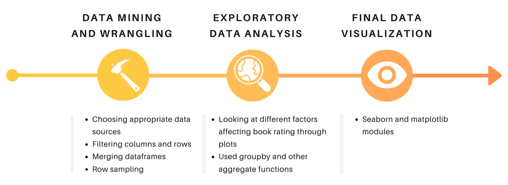

```python
Image(filename="Our Methodology.PNG")
```

### 4.1 DATA MINING and WRANGLING

#### 4.1.1 Choosing appropriate data sources

Book genres were chosen using the following criteria:

- Has both `books` and `interactions` JSON files available.
- Has at least 1 million rows in the `interactions` JSON file.

These criteria were chosen to enable equal and enough sampling of data when these genres are merged into one pandas DataFrame. The genres to be analyzed are - fantasy/paranormal, comics, young adult, history and biography, romance and children. The mystery/thriller and poetry genres were excluded since they did not meet our chosen criteria.

#### 4.1.2 Filtering columns and rows

For each of the genres selected, the following cleaning and manipulation steps were performed on the respective `books` JSON file:

- Read first N rows of JSON file where N was manually chosen for each genre such that enough data is available, while avoiding overloading of the server (suggestion: instances of DataFrame building failure). Store in pandas DataFrame named `df_books`.

**Table 4.1 Number of rows read from each genre.**

| Genre | N rows extracted |
| --- | --- |
| Fantasy/Paranormal | 100,000 |
| Comics | 80,000 |
| Young Adult | 90,000 |
| History and Biography | 100,000 |
| Romance | 100,000 |
| Children | 100,000 |

- Remove rows with `rating count < 500`. This value was set to ensure only well-reviewed books are included in the analysis.
- Unnecessary columns were removed.
- Afterwards, a list of `book ID`s present in `df_books` was generated. This will be used in the cleaning of the `interactions` dataset.

Likewise, each of the `interactions` JSON files were also subject to the following operations:

- Read first 1 million rows of JSON file and store in a pandas DataFrame named `df_interact`. This limitation was made to avoid overloading the server as there are multiple genres.
- Unnecessary columns were removed.
- Remove rows with `book ID`s not included in `df_books` to avoid null values and lessen computational resources needed in succeeding steps.
- Remove rows that has an empty string value for `read_at` and `started_at` columns.

#### 4.1.3 Merging data from `df_books` and `df_interact`

- Convert `read_at` and `started_at` columns of `df_interact` to datetime type.
- Create a new column `read_duration` in `df_interact` that contains reading duration in days. This value was determined from the difference of the `read_at` and `started_at` columns.
- Calculate average rating and average reading duration each book ID in df_interact by using `groupby` function.
- Insert average rating and average reading duration columns in `df_books` as, mapping based on book ID.
- Drop rows in `df_books` that has a null value for both of the added columns or having negative value for reading duration.
- Sample 5,000 rows from the remaining rows of `df_books`.
- Add a column 'genre' to label the sampled rows before appending it to the Goodreads_Sampled.csv file, containing all the genre processed and updated in every loop.

#### Code for Generating Goodreads_Sampled.csv

```python
path1 = '/mnt/data/public/bookgraph/goodreads_books_'
path2 = '/mnt/data/public/bookgraph/goodreads_interactions_'

files = ['fantasy_paranormal.json.gz',
         'comics_graphic.json.gz',
         'young_adult.json.gz',
         'history_biography.json.gz',
         'romance.json.gz',
         'children.json.gz']

x = 0  # counter

book_nrows = [100_000, 80_000, 90_000, 100_000, 100_000, 100_000]

for file in files:
    df_books = pd.read_json(path1 + file, lines=True, nrows=book_nrows[x])
    df_interact = pd.read_json(path2 + file, lines=True, nrows=1_000_000)

    df_books = df_books[df_books['ratings_count'] > 500]

    # Useful columns for df_books
    cols = ['book_id',
            'is_ebook',
            'text_reviews_count',
            'average_rating',
            'language_code',
            'num_pages',
            'publication_month',
            'publication_year',
            'ratings_count',
            'title']

    df_books = df_books[cols]
    book_list = df_books['book_id'].tolist()

    # Useful columns for df_interact
    cols = ['user_id',
            'book_id',
            'review_id',
            'is_read',
            'rating',
            'date_added',
            'read_at',
            'started_at']
    df_interact = df_interact[cols]

    df_interact = df_interact[df_interact['book_id'].isin(book_list)]
    df_interact['is_read2'] = ((df_interact['started_at'].str.len() > 0) &
                               (df_interact['read_at'].str.len() > 0))
    df_interact = df_interact[df_interact['is_read2'] == True]

    df_interact['started_at'] = pd.to_datetime(df_interact['started_at'],
                                               utc=True)
    df_interact['read_at'] = pd.to_datetime(df_interact['read_at'],
                                            utc=True)
    df_interact['read_duration'] = ((df_interact['read_at'] -
                               df_interact['started_at']).dt.days)

    sample_rating = df_interact.groupby('book_id')['rating'].mean()

    df_books['sample_rating'] = df_books['book_id'].map(sample_rating)
    df_books = df_books[df_books.sample_rating > 0]
    df_books.dropna(subset=['sample_rating'], inplace=True)

    sample_duration = df_interact.groupby('book_id')['read_duration'].mean()

    df_books['read_duration'] = df_books['book_id'].map(sample_duration)
    df_books = df_books[df_books.read_duration >= 0]
    df_books.dropna(subset=['read_duration'], inplace=True)

    df_books['genre'] = file.split('.')[0]
    df_books = df_books.sample(5000, random_state=42)

    if x == 0:
        df_books.to_csv('Goodreads_Sampled.csv',
                        mode='w',
                        header=True,
                        index=False)
    else:
        df_books.to_csv('Goodreads_Sampled.csv',
                        mode='a',
                        header=False,
                        index=False)
    del df_books
    del df_interact

    x += 1
```

#### 4.1.4 Data Disclaimer

Note that since only the first 1 million rows are read from the `interactions` JSON file for each genre, there is a discrepancy with the population mean of the average rating (`average_rating` column) and the mean of the sampled rows (`sample_rating` column).

```python
df = pd.read_csv('Goodreads_Sampled.csv')

df.replace({'fantasy_paranormal' : 'Fantasy/Paranormal',
            'comics_graphic' : 'Comics/Graphic',
            'young_adult' : 'Young Adult',
            'history_biography' : 'History/Biography',
            'romance' : 'Romance',
            'children' : 'Children'}, inplace=True)
```

**Figure 4.2 Comparison of average rating with sample rating**

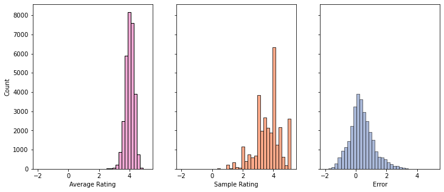

```python
# Plot average and sample rating, along with its error
df_c = df.copy()
df_c['error'] = df_c['average_rating'] - df_c['sample_rating']

fig, (ax1, ax2, ax3) = plt.subplots(1, 3,
                                    sharex=True,
                                    sharey=True)

plt.gcf().set_size_inches(12,5)
sns.histplot(data=df_c, x="average_rating",
             ax=ax1, binwidth=0.2,
             color='#e78ac3').set_xlabel('Average Rating')

sns.histplot(data=df_c, x="sample_rating",
             ax=ax2, binwidth=0.2,
             color='#fc8d62').set_xlabel('Sample Rating')

sns.histplot(data=df_c, x="error",
             ax=ax3, binwidth=0.2, color='#8da0cb').set_xlabel('Error')

display(HTML('<center style="font-size:12px;font-style:default;">'
             '<b>Figure 4.2 Comparison of average rating with '
             'sample rating</b></center>'))
```

### 4.2 EXPLORATORY DATA ANALYSIS (EDA)

EDA was performed with aggregate functions and various visualization techniques. The objective was to gather insights from the different factors affecting book ratings.

### 4.3 FINAL DATA VISUALIZATION

The `matplotlib` and `seaborn` modules were used to plot the insightful relationships noted in the Exploratory Data Analysis stage.

# 5. Results

The preceding chapter discussed the procedures and techniques needed to come up with the results. In this section, the interpretation of the data will be presented. First, rating related insights will be discussed whether or not it is affected by average duration and other book features. Next, non-rating related features will be inspected to see if a correlation to other features can be found. The discovered key takeaways will be discussed in this section.

## 5.1 Factors Affecting Book Rating

There are two main thoughts for rating-related results. First, the average rating vs. average duration will be examined to see if they have some kind of relationship as whole and per genre. Then, other features will be checked to see if they have connection to average rating. These features are rating count, text review count, number of pages, language, e-book, and publication date.

### 5.1.1 Average Rating vs. Average Reading Duration

Before proceeding to examining the relationship of average rating and average duration, let's look at the averages per genre.

**Figure 5.1 Average Duration per Genre**

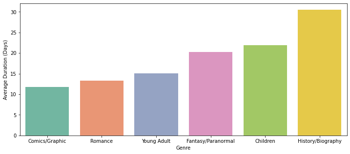

```python
# Load Main DataFrame
df_big = df.copy()
df_big = df.loc[df['read_duration'] > 0]

# Create dataframe for average duration per genre
df_dur = (df_big.groupby('genre')['read_duration'].mean()
          .sort_values().reset_index())

# Plot average duration per genre
display(HTML('<center style="font-size:12px;font-style:default;">'
             '<b>Figure 5.1 Average Duration per Genre</b></center>'))

sns.barplot(x='genre', y='read_duration', data=df_dur, palette='Set2')
plt.gcf().set_size_inches(12, 5)
plt.xlabel('Genre')
plt.ylabel('Average Duration (Days)')
plt.show()
```

**Figure 5.2 Average Rating per Genre**

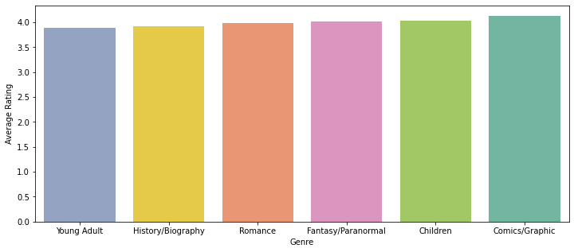

```python
# Set palette for average rating per genre to match previous chart
palette_set2 = np.array(sns.color_palette("Set2"))
palette2 = np.array([palette_set2[2], palette_set2[5],
                     palette_set2[1], palette_set2[3],
                     palette_set2[4], palette_set2[0]])

# Create dataframe for average rating per genre
df_rat = (df_big.groupby('genre')['average_rating'].mean()
          .sort_values().reset_index())

# Plot average rating per genre
display(HTML('<center style="font-size:12px;font-style:default;">'
             '<b>Figure 5.2 Average Rating per Genre</b></center>'))

sns.barplot(x='genre',
            y='average_rating',
            data=df_rat,
            palette=palette2)
plt.gcf().set_size_inches(12, 5)
plt.xlabel('Genre')
plt.ylabel('Average Rating')
plt.show()
```

From the bar chart above, history and biography books are the longest to read while comics and graphics are the fastest to read. This is due to the texts associated with them. Most comics/graphics have less words while history/biography books are verbose in nature.

The second bar chart indicates that there are small differences with average rating. This suggests that book genre may not affect the ratings of the book.

Now, let's see if average rating has an association with average duration. Below are the scatter plot and bar chart (in buckets) of average rating vs. average duration.

**Figure 5.3 Average Reading Duration vs. Average Rating**

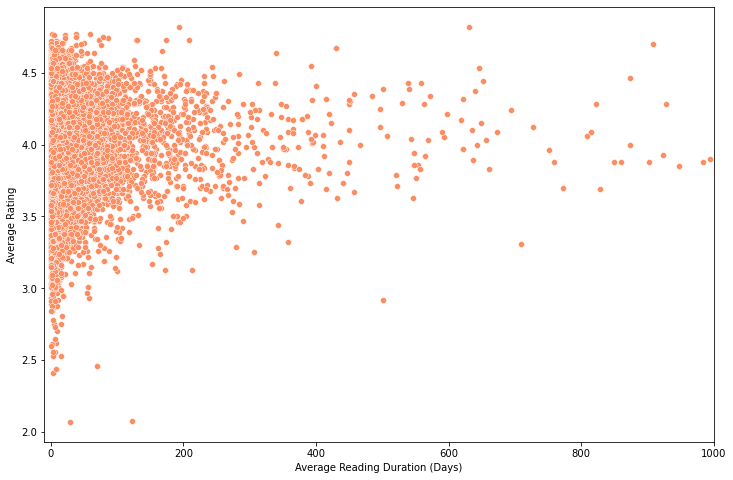

```python
# Plot ave rating vs ave duration
display(HTML('<center style="font-size:12px;font-style:default;">'
             '<b>Figure 5.3 Average Reading Duration vs. Average Rating</b>'
             '</center>'))

sns.scatterplot(data=df_big,
                x="read_duration",
                y="average_rating",
                color=palette_set2[1])
plt.xlim(-10, 1000)
plt.xlabel('Average Reading Duration (Days)')
plt.ylabel('Average Rating')
plt.show()
```

In the scatterplot above, it looks like the data is spread and no trend can be found. It shows that average rating and average duration may not have a relationship. One thing we can see here though is that most books are finished below 200 days of reading.

To double check, the reading duration will be grouped in buckets to see if something can be found. Below is the bar chart.

**Figure 5.4 Average Rating vs. Average Reading Duration(Days)**

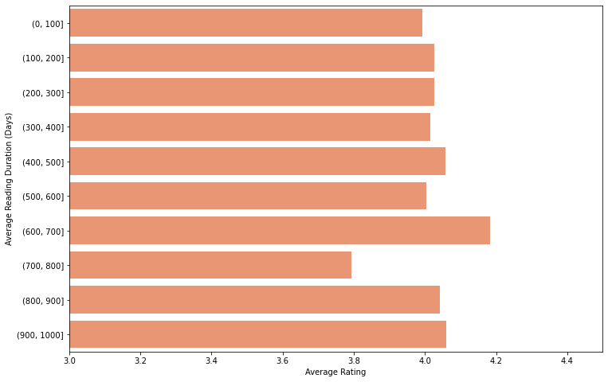

```python
# Create a dataframe for rate vs duration bar chart
df_dur = df_big.copy()
df_dur['dur_range'] = 0
mindur = df_dur['read_duration'].min()
maxdur = df_dur['read_duration'].max()
page_range = np.arange(0, 1001, 100)
df_dur = (df_dur.groupby(pd.cut(df_dur["read_duration"],
                                page_range))['average_rating'].mean())
df_dur = df_dur.reset_index()
df_dur = df_dur.astype({'read_duration': 'str'})

# Plot rate vs duration bar chart
display(HTML('<center style="font-size:12px;font-style:default;">'
             '<b>Figure 5.4 Average Rating vs. Average Reading Duration'
             '(Days)</b></center>'))

sns.barplot(x='average_rating',
            y='read_duration',
            data=df_dur,
            palette=np.repeat([palette_set2[1]], 10, axis=0))

plt.ylabel('Average Reading Duration (Days)')
plt.xlabel('Average Rating')
plt.xlim(3, 4.5)
plt.show()
```

As seen on the chart above, no trend can be found between rating and reading duration. It may be due to the fact that different people have different paces of reading. Also, some books are easier to read than the others.

**Figure 5.5 Average Reading Duration vs. Average Rating per Genre**

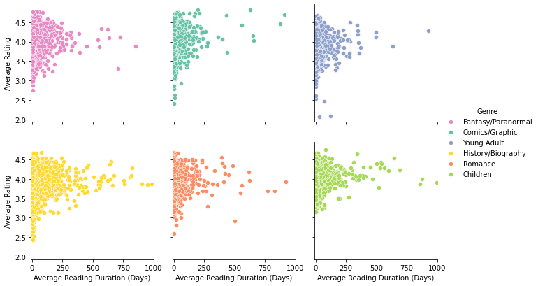

```python
display(HTML('<center style="font-size:12px;font-style:default;">'
             '<b>Figure 5.5 Average Reading Duration vs. Average Rating per '
             'Genre</b></center>'))

palette3 = np.array([palette_set2[3], palette_set2[0],
                     palette_set2[2], palette_set2[5],
                     palette_set2[1], palette_set2[4]])

g = sns.FacetGrid(df_big, col="genre", hue="genre", palette=palette3,
                  xlim=(-10,1000), col_wrap=3)
g.map(sns.scatterplot, "read_duration", "average_rating")
g.set(xlabel='Average Reading Duration (Days)',
      ylabel='Average Rating', title=None)
g.add_legend(title='Genre');
```

Likewise, the genre of the book and the length it was read does not impact the rating provided to the book.

### 5.1.2 Average Rating vs. Other Book Features

#### 5.1.2.1 Number of Ratings and Text Reviews

```python
# Copy Main DF
df_rc = df_big.copy()

# Create dataframe with rating and text review counts
df_rc = df_rc[['average_rating', 'sample_rating', 'text_reviews_count',
               'ratings_count', 'genre']]
```

**Figure 5.6 Average Rating vs. Number of Ratings**

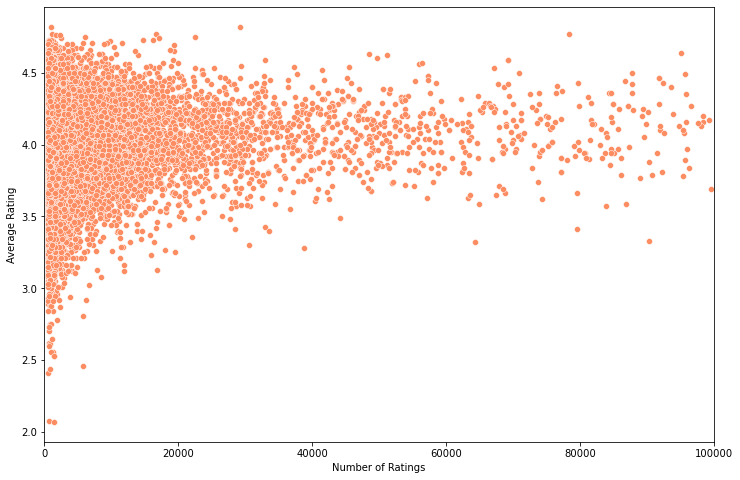

```python
# Plot Average Rating vs Ratings Count
display(HTML('<center style="font-size:12px;font-style:default;">'
             '<b>Figure 5.6 Average Rating vs. Number of Ratings</b>'
             '</center>'))

sns.scatterplot(y="average_rating", x="ratings_count", data=df_rc,
                color=palette_set2[1])
plt.xlim(-10, 100000)
plt.ylabel('Average Rating')
plt.xlabel('Number of Ratings')
plt.show()
```

As seen from the scatter plot above, there seems to be no direct correlation between the average rating and the number of ratings per book because the data points are too distributed. Though it can be inferred that most of those with higher number of ratings tend to have a rating between 3.5 to 4.5.  
Meanwhile, the bar plot below shows that as the number of ratings increase, the average rating increases as well.

**Figure 5.7 Average Rating vs. Number of Ratings**

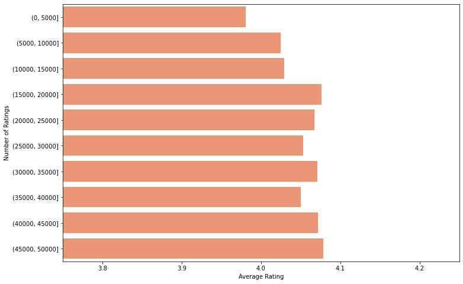

```python
# Plot Average Rating vs Ratings Count (Bins)
rc_range = np.arange(0, 55000, 5000)
df_1 = df_rc.groupby(pd.cut(df_rc["ratings_count"],
                                rc_range))['average_rating'].mean()
df_1 = df_1.reset_index()
df_1 = df_1.astype({'ratings_count': 'str'})

display(HTML('<center style="font-size:12px;font-style:default;">'
             '<b>Figure 5.7 Average Rating vs. Number of Ratings</b>'
             '</center>'))

sns.barplot(x='average_rating',
            y='ratings_count',
            data=df_1,
            palette=np.repeat([palette_set2[1]], 10, axis=0))
plt.xlabel('Average Rating')
plt.ylabel('Number of Ratings')
plt.xlim(3.75, 4.25)
plt.show()
```

#### 5.1.2.2 Number of Text Reviews

**Figure 5.8 Average Rating vs. Number of Text Review**

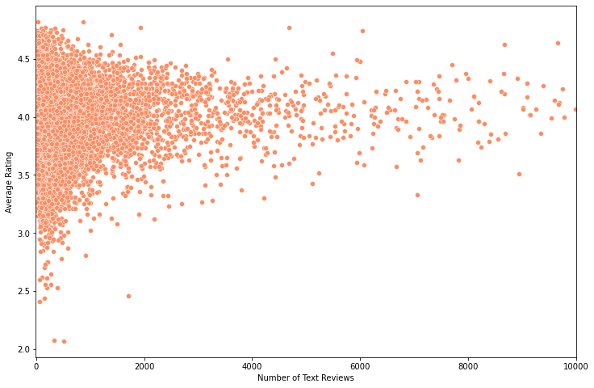

```python
# Plot Average Rating vs Text Review Count
display(HTML('<center style="font-size:12px;font-style:default;">'
             '<b>Figure 5.8 Average Rating vs. Number of Text Review</b>'
             '</center>'))

sns.scatterplot(y="average_rating", x="text_reviews_count", data=df_rc,
                color=palette_set2[1])
plt.xlim(-10, 10000)
plt.ylabel('Average Rating')
plt.xlabel('Number of Text Reviews')
plt.show()
```

The same analysis can be made when it comes to the average ratings compared to the number of text reviews per book. Mostly no trend is observed but the higher number of reviews usually cluster between ratings of 3.5 and 4.5.

The bar graph doesn't show a clear increasing trend compared to the bar plot for the number of the ratings. The results here are more varied.

**Figure 5.9 Average Rating vs. Number of Text Reviews**

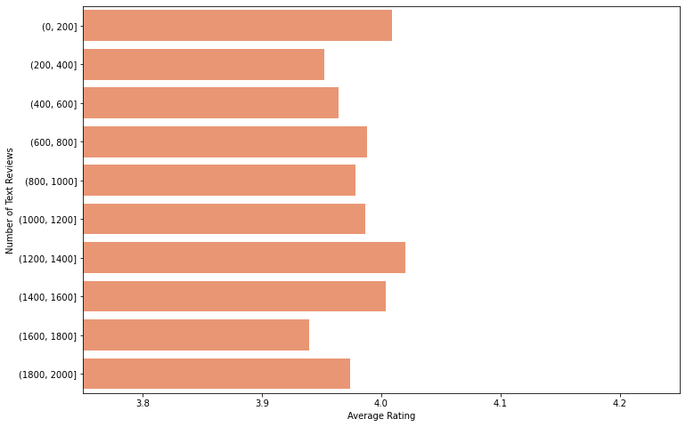

```python
# Plot Average Rating vs Text Review Count (Bins)
rc_range = np.arange(0, 2200, 200)
df_2 = df_rc.groupby(pd.cut(df_rc["text_reviews_count"],
                            rc_range))['average_rating'].mean()
df_2 = df_2.reset_index()
df_2 = df_2.astype({'text_reviews_count': 'str'})

display(HTML('<center style="font-size:12px;font-style:default;">'
             '<b>Figure 5.9 Average Rating vs. Number of Text Reviews</b>'
             '</center>'))

sns.barplot(x='average_rating',
            y='text_reviews_count',
            data=df_2,
            palette=np.repeat([palette_set2[1]], 10, axis=0))
plt.xlabel('Average Rating')
plt.ylabel('Number of Text Reviews')
plt.xlim(3.75, 4.25)
plt.show()
```

#### 5.1.2.3 Number of Pages

**Figure 5.10 Average Rating vs. Numberof Pages**

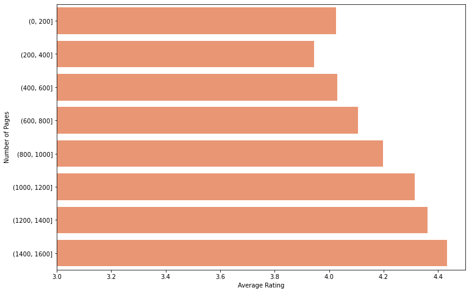

```python
# Create a dataframe for Rating vs Number of Pages
df_num = df_big.copy()
df_num['pag_range'] = 0
minpage = df_num['num_pages'].min()
maxpage = df_num['num_pages'].max()
page_range = np.arange(0, 1800, 200)
df_num = df_num.groupby(pd.cut(df_num["num_pages"],
                               page_range))['average_rating'].mean()
df_num = df_num.reset_index()
df_num = df_num.astype({'num_pages': 'str'})

# Plot Average Rating vs Number of Pages in a  bar chart
display(HTML('<center style="font-size:12px;font-style:default;">'
             '<b>Figure 5.10 Average Rating vs. Number'
             'of Pages</b></center>'))

sns.barplot(x='average_rating',
            y='num_pages',
            data=df_num,
            palette=np.repeat([palette_set2[1]], 10, axis=0))
plt.ylabel('Number of Pages')
plt.xlabel('Average Rating')
plt.xlim(3, 4.5)
plt.show()
```

Short stories or those that are 200 pages or less have an average rating of 4, which is already high. Starting at more than 200 pages, the book ratings become higher as the number of pages increases.

#### 5.1.2.4 Book Format (E-Book or Print)

We note that whether a book is available as an e-book or not will not affect the average rating significantly.

**Figure 5.11 Average Rating per Book Format**

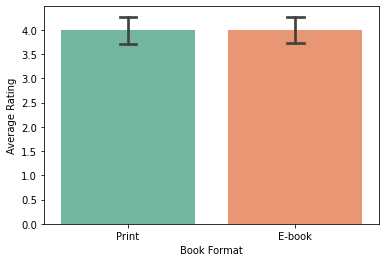

```python
display(HTML('<center style="font-size:12px;font-style:default;">'
             '<b>Figure 5.11 Average Rating per Book Format</b></center>'))

sns.barplot(x=df["is_ebook"], y=df["average_rating"], palette="Set2",
            ci='sd', capsize=.1).set_xticklabels(['Print','E-book'])
plt.gcf().set_size_inches(6,4)
plt.xlabel('Book Format')
plt.ylabel('Average Rating')
plt.show()
```

#### 5.1.2.5 Language Code

**Figure 5.12 Language vs. Average Rating**

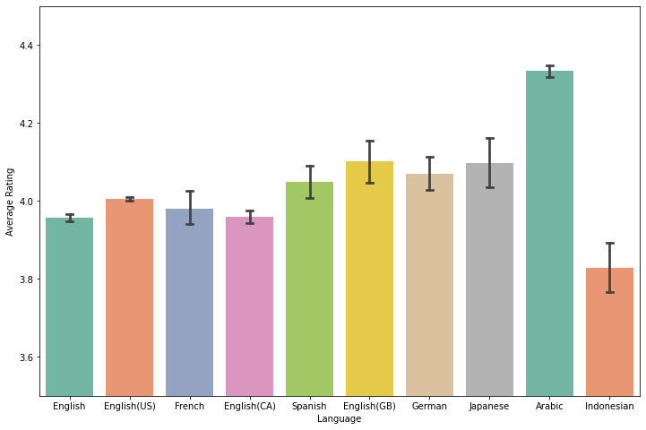

```python
df_lang = df_big[['average_rating', 'sample_rating',
                  'language_code', 'genre']]

# Take languages with 50 or more books
counts = df_lang['language_code'].value_counts()
df_lang = df_lang[df_lang['language_code'].isin(counts[counts > 50].index)]

list_lang = ['English', 'English(US)', 'French', 'English(CA)',
             'Spanish', 'English(GB)', 'German', 'Japanese', 'Arabic',
             'Indonesian']

display(HTML('<center style="font-size:12px;font-style:default;">'
             '<b>Figure 5.12 Language vs. Average Rating</b></center>'))

sns.barplot(x="language_code", y="average_rating", data=df_lang,
            palette='Set2', capsize=.1).set_xticklabels(list_lang)

plt.ylabel('Average Rating')
plt.xlabel('Language')
plt.ylim(3.5, 4.5)
plt.show()
```

The top 10 recorded languages (50 or more books) were observed versus their corresponding average ratings. Arabic books have the highest average rating while Indonesian books got the lowest average ratings.

#### 5.1.2.6 Publication Year

We next explore if the year the book was published may have an impact to book ratings.

**Figure 5.13 Average Ratings accross Publication Year**

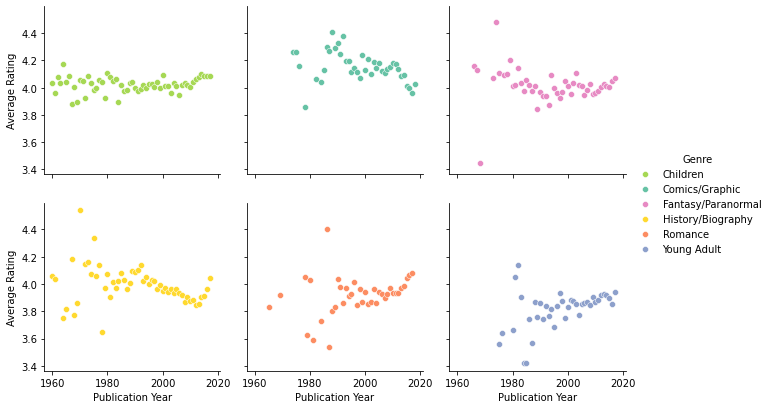

```python
# Create a dataframe for Average Duration vs Number of Pages
df_year = df_big.copy()
df_year = df_year[(df_year['publication_year'] <= 2021)
             & (df_year['publication_year'] >= 1960)]
df_year = pd.pivot_table(df_year, values='average_rating',
                         columns=['genre'],
                         index=['publication_year'],
                         aggfunc='mean',
                         margins=False)
df_year = pd.melt(df_year, ignore_index=False, value_name='average_rating')
df_year = df_year.reset_index()
df_year['publication_year'] = pd.to_datetime(df_year['publication_year'],
                                             format='%Y')
df_year['publication_year'] = (pd.DatetimeIndex(df_year
                                                ['publication_year']).year)

# Supress FutureWarning
warnings.simplefilter(action='ignore', category=FutureWarning)

# Plot Average Rating across Publication Year for each Genre
palette_set2 = np.array(sns.color_palette("Set2"))
paletteyears = np.array([palette_set2[4], palette_set2[0],
                     palette_set2[3], palette_set2[5],
                     palette_set2[1], palette_set2[2]])

year = sns.FacetGrid(df_year, col="genre", hue="genre",
                     palette=paletteyears, col_wrap=3)
year.map(sns.scatterplot, "publication_year", "average_rating")
year.set(xlabel='Publication Year', ylabel='Average Rating', title=None)
year.add_legend(title='Genre')

display(HTML('<center style="font-size:12px;font-style:default;">'
             '<b>Figure 5.13 Average Ratings accross Publication Year</b>'
             '</center>'))
```

We can observe from the graphs that goodreads.com users rate books in a more stable manner for books published approximately between 2000 and mid-2010s. In contrast, books published earlier in the millenium would have more varying ratings. From this, we can infer that either the rating criteria or the writing quality has converged to a universal "standard" for works published more recently.

**Figure 5.14 Upper Bound and Lower Bound Ratingsper Genre**

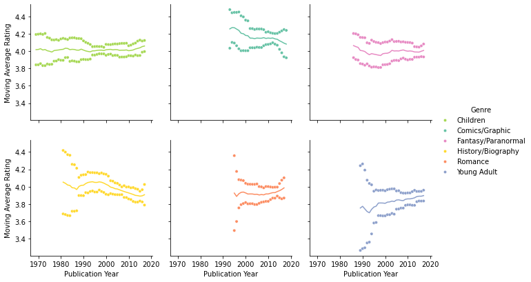

```python
# Generate Mean and Standard Deviation Columns for the Rating per genre
df_year['publication_year'] = pd.to_datetime(df_year['publication_year'],
                                             format='%Y')
df_year = df_year.set_index('publication_year')
df_year['roll_mean'] = df_year['average_rating'].rolling(10).mean()
df_year['roll_std'] = df_year['average_rating'].rolling(10).std()
df_year['upper_bound'] = df_year['roll_mean'] + 2*df_year['roll_std']
df_year['lower_bound'] = df_year['roll_mean'] - 2*df_year['roll_std']
df_year = df_year.reset_index()
yearavestd = sns.FacetGrid(df_year, col="genre", hue="genre",
                           palette=paletteyears, col_wrap=3)
yearavestd.map(sns.lineplot, "publication_year", "roll_mean")
yearavestd.map(sns.scatterplot, "publication_year", "upper_bound",
               size=0.5)
yearavestd.map(sns.scatterplot, "publication_year", "lower_bound",
               size=0.5)
yearavestd.set(xlabel='Publication Year', ylabel='Moving Average Rating',
               title=None)

yearavestd.add_legend(title='Genre')

display(HTML('<center style="font-size:12px;font-style:default;">'
             '<b>Figure 5.14 Upper Bound and Lower Bound Ratings'
             'per Genre</b></center>'))
```

## 5.2 Other Feature Interactions

The following features were also checked against each other for possible correlations:

| Feature |
| --- |
| Book Format (E-book) |
| Number of Pages |
| Reading Duration |
| Publication Year |
| Number of Ratings |
| Number of Text Reviews |
| Genre |

**Figure 5.15 Book Feature Interactions Pairplot**

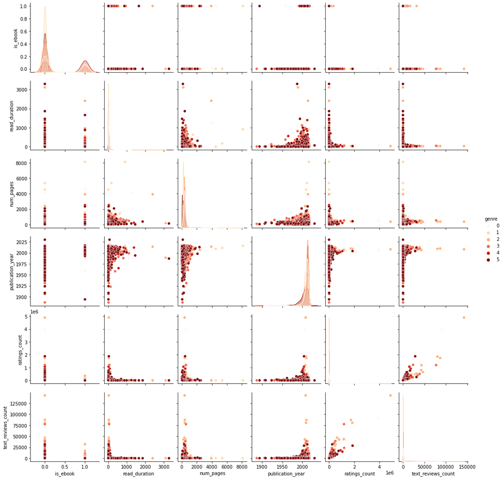

```python
df_pp = df_big.copy()

# Convert is_ebook into 0/1
df_pp["is_ebook"] = df_pp["is_ebook"].astype(int)

# Convert genre into numerical equivalent
df_pp.replace({'Fantasy/Paranormal' : 0, 'Comics/Graphic' : 1,
               'Young Adult' : 2, 'History/Biography' : 3,
               'Romance' : 4, 'Children' : 5}, inplace=True)

# Pairplot for the 7 features
display(HTML('<center style="font-size:12px;font-style:default;">'
             '<b>Figure 5.15 Book Feature Interactions Pairplot</b>'
             '</center>'))

sns.pairplot(vars=['is_ebook',
                   'read_duration',
                   'num_pages',
                   'publication_year',
                   'ratings_count',
                   'text_reviews_count',
                   ], diag_kind="kde",
             hue='genre', data=df_pp, palette='OrRd')
plt.show()
```

#### 5.2.1 Book Format (E-Book)

The book format is not related to the number of pages and the average reading time. Meanwhile a higher number of ratings and text reviews can be associated more to hard copies. Most of the available e-books are also from a more recent publication year. This is expected because most of the older books are not available in a digital format.

It is interesting to note the differences in the percentage of book format distribution. The highest of which is the romance genre. This could be due to its target audience -- young to middle-aged adults, and the ease of access e-books give them. Another possible reason, is that e-books are more discreet and hence, more favored for the romance genre.

The genres with the lowest percentage of e-books are children's books and comics. This is also likely due to the target consumers of these books - toddlers, teenagers and comic book collectors. Parents would not want their children to be staring at screens as it may damage their developing vision. And comic book fans may want to collect physical copies of these books, even after reading them.

**Figure 5.16 Distribution of Book Format per Genre**

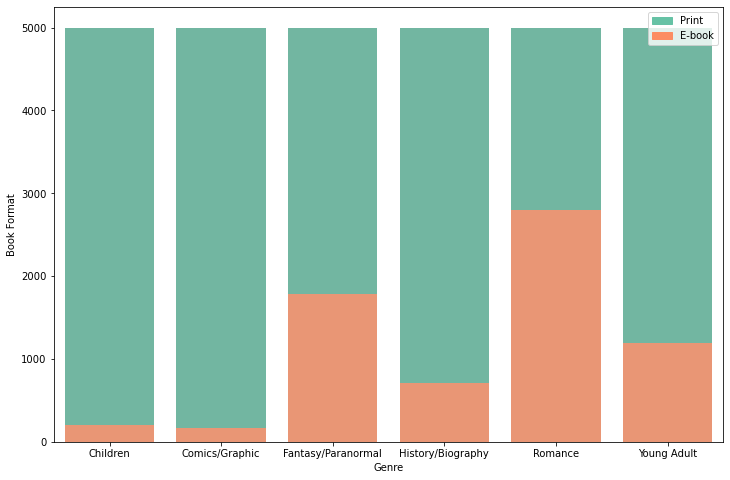

```python
# from raw value to percentage
total = df.groupby('genre')['is_ebook'].count().reset_index()
ebook = (df[df.is_ebook==True].groupby('genre')['is_ebook']
         .sum().reset_index())

# bar chart 1 -> top bars
display(HTML('<center style="font-size:12px;font-style:default;">'
             '<b>Figure 5.16 Distribution of Book Format per Genre</b>'
             '</center>'))

bar1 = sns.barplot(x="genre", y="is_ebook", data=total, color='#66c2a5')

# bar chart 2 -> bottom bars
bar2 = sns.barplot(x="genre", y="is_ebook", data=ebook, color='#fc8d62')

top_bar = mpatches.Patch(color='#66c2a5', label='Print')
bottom_bar = mpatches.Patch(color='#fc8d62', label='E-book')
plt.ylabel('Book Format')
plt.xlabel('Genre')
plt.legend(handles=[top_bar, bottom_bar])

plt.show()
```

We find that reading duration is around 5 days faster on average when the material is present in e-book format. This is likely due to the high accessibility of e-books in this digital age. One could read practically anywhere without bringing a physical copy.

**Figure 5.17 Comparison of Reading Duration per Book Format**

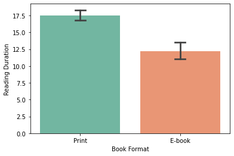

```python
display(HTML('<center style="font-size:12px;font-style:default;">'
             '<b>Figure 5.17 Comparison of Reading Duration per Book Format'
             '</b></center>'))

sns.barplot(x=df["is_ebook"], y=df["read_duration"], palette="Set2",
             capsize=.1).set_xticklabels(['Print','E-book'])
plt.xlabel('Book Format')
plt.ylabel('Reading Duration')
plt.gcf().set_size_inches(6,4)
```

#### 5.2.2 Number of Pages and Duration

These two features have the same relationship to the other features analyzed. Generally, higher number of pages also translate to longer reading time. As for the publication year, older books tend to have fewer number of pages/shorter reading time.

**Figure 5.18 Average Duration (Days) vs. Number of Pages**

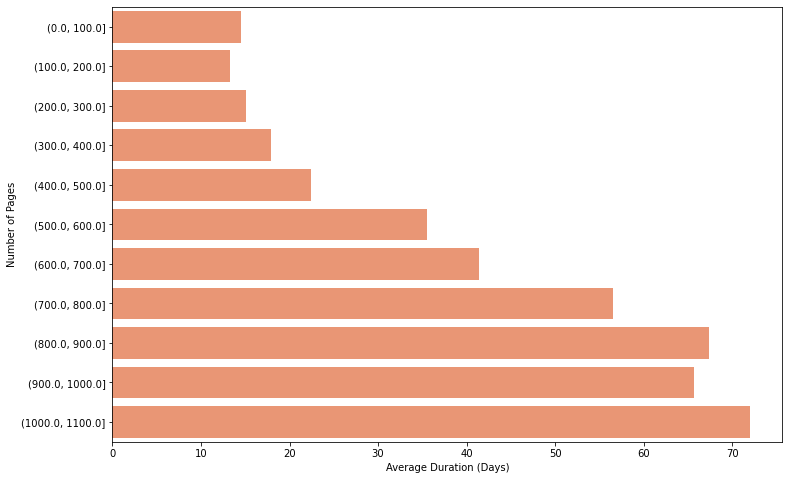

```python
# Create a dataframe for Average Duration vs Number of Pages
df_num2 = df_big.copy()
df_num2['dur_range'] = 0
minpage = df_num2['num_pages'].min()
maxpage = df_num2['num_pages'].max()
page_range = np.arange(minpage, 1101, 100)
df_num2 = df_num2.groupby(pd.cut(df_num2["num_pages"], page_range))\
            ['read_duration'].mean()
df_num2 = df_num2.reset_index()
df_num2 = df_num2.astype({'num_pages': 'str'})

# Plot Average Duration vs Number of Pages in a  bar chart
display(HTML('<center style="font-size:12px;font-style:default;">'
             '<b>Figure 5.18 Average Duration (Days) vs. Number of Pages</b>'
             '</center>'))

sns.barplot(x='read_duration',
            y='num_pages',
            data=df_num2,
            color=palette_set2[1])
plt.xlabel('Average Duration (Days)')
plt.ylabel('Number of Pages')
plt.show()
```

#### 5.2.3 Number of Ratings and Text Reviews

These features are directly proportional to each other. More ratings usually translate to more text reviews as well. A higher count for both can be observed for those with more recent publication years and those with fewer pages/shorter reading time.

**Figure 5.19 Number of Text Reviews vs. Number of Ratings**

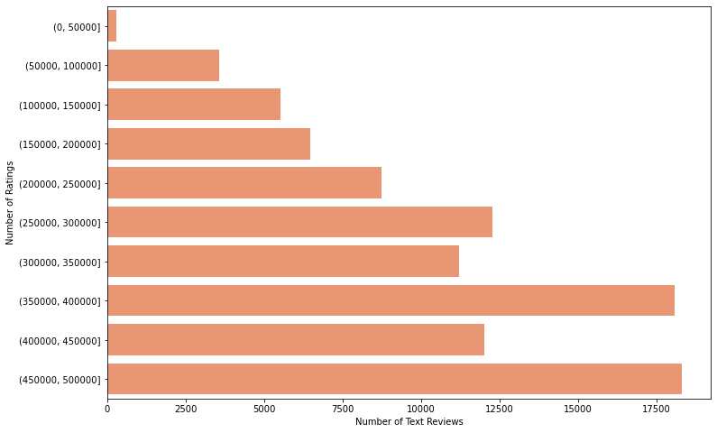

```python
rc_range = np.arange(0, 550000, 50000)
df_3 = df_rc.groupby(pd.cut(df_rc["ratings_count"],
                            rc_range))['text_reviews_count'].mean()
df_3 = df_3.reset_index()
df_3 = df_3.astype({'ratings_count': 'str'})

display(HTML('<center style="font-size:12px;font-style:default;">'
             '<b>Figure 5.19 Number of Text Reviews vs. Number of Ratings</b>'
             '</center>'))

sns.barplot(x='text_reviews_count',
            y='ratings_count',
            data=df_3,
            color=palette_set2[1])
plt.xlabel('Number of Text Reviews')
plt.ylabel('Number of Ratings')
plt.show()
```

Comparing the number of ratings and text reviews showed that more ratings also usually means more text reviews. Results may vary in higher bins of rating counts due to lower sample size.

## 6. Conclusion and Recommendation

As a website, Goodreads.com has enabled its users and members to view friends’ bookshelves, share comments and provide ratings for each book available in the website. These ratings can provide an indication of the quality of a book.  
The relationship of the different book features with the average book rating were analyzed through a series of aggregations and visualizations in order to determine the factors that influence a book rating. We found that the reading duration is not a significant predictor of book ratings. However, the number of book pages is directly proportional to book ratings. This is likely due to the generally long-story formats of acclaimed novels or epics and the engrossment of avid readers to the material. The same explanation would also make sense for the direct relationship between ratings count and book ratings, implying that readers are more inclined to submit a review for the books they like. Lastly, books which are more recently published have lesser variability in their ratings, signifying convergence to a universal ‘standard’.  
Notable insights from the other features include the book format's effect on the reading time due to portability, and the preference of book format per genre, most evident in comics and children’s books.  
One of the more obvious direct relations is between reading duration and the number of pages. There is also an apparent direct relation between the number of ratings and number of text reviews which can be attributed to an increase in engagement for extreme high or low ratings.  
Our group advises authors to consider putting all their passion into writing their books and avoid thinking too much about the length of the book. The quality of books is increasing yearly and our group suggests writers to read more books so that their writing and ideas improve. Advertisers, and publishers can also leverage the insights on this analysis. Advertisers may actively encourage their readers to share their thoughts on the book in Goodreads. In a fairly similar consumer behavior in e-commerce, people tend to trust products with good ratings accompanied by sufficient text reviews.  
In future study on Goodreads data, it would be interesting to look into user profiles like their age, gender, and other demographic and psychometric information of the reviewers.  
The Goodreads data has further information that can be mined and analyzed. Possible next steps include performing machine learning algorithms to assess the expected rating of an author’s next book, possible book recommendation algorithms and other analyses.

## 7. References

We would like to acknowledge our references for this study:

- Mengting Wan, Julian McAuley, "Item Recommendation on Monotonic Behavior Chains", in RecSys'18. [bibtex]
- Mengting Wan, Rishabh Misra, Ndapa Nakashole, Julian McAuley, "Fine-Grained Spoiler Detection from Large-Scale Review Corpora", in ACL'19. [bibtex]
- APA: Goodreads. (n.d.). About Goodreads. Goodreads. https://www.goodreads.com/about/us
- UCSD Book Graph. (n.d.). https://sites.google.com/eng.ucsd.edu/ucsdbookgraph/home
- WIkipedia (n.d.). https://en.wikipedia.org/wiki/Goodreads